# Quiz 3

## 1)

Load the cell segmentation data from the AppliedPredictiveModeling package.

1. Subset the data to a training set and testing set based on the Case variable in the data set.
2. Set the seed to 125 and fit a CART model with the rpart method using all predictor variables and default caret settings.
3. In the final model what would be the final model prediction for cases with the following variable values:
   1. TotalIntench2 = 23,000; FiberWidthCh1 = 10; PerimStatusCh1=2
   2. TotalIntench2 = 50,000; FiberWidthCh1 = 10;VarIntenCh4 = 100
   3. TotalIntench2 = 57,000; FiberWidthCh1 = 8;VarIntenCh4 = 100
   4. FiberWidthCh1 = 8;VarIntenCh4 = 100; PerimStatusCh1=2

```r
data(segmentationOriginal)
#str(segmentationOriginal)

set.seed(125)

inTrain <- createDataPartition(y=segmentationOriginal$Case,
                              p=0.6, list=FALSE)
training <- segmentationOriginal[inTrain,]
testing <- segmentationOriginal[-inTrain,]

dim(training)
```

```
[1] 1212  119
```

```r
dim(testing)
```

```
[1] 807 119
```

From `?segmentationOriginal` I discovered that:

The data consists of 119 imaging measurements on 2019. The original analysis used 1009 for training and 1010 as a test set (see the column called Case).

The outcome class is contained in a factor variable called Class with levels “PS” for poorly segmented and “WS” for well segmented.

(This question was not very well formulated)

```r
# `rpart` does regression in classigication trees
modFit <- train(Class ~ .,method="rpart",data=training)

modFit$finalModel
```

```
n= 1212

node), split, n, loss, yval, (yprob)
      * denotes terminal node

1) root 1212 437 PS (0.63943894 0.36056106)
  2) TotalIntenCh2< 42420.5 524  31 PS (0.94083969 0.05916031) *
  3) TotalIntenCh2>=42420.5 688 282 WS (0.40988372 0.59011628)
    6) FiberWidthCh1< 9.908058 211  74 PS (0.64928910 0.35071090) *
    7) FiberWidthCh1>=9.908058 477 145 WS (0.30398323 0.69601677) *
```

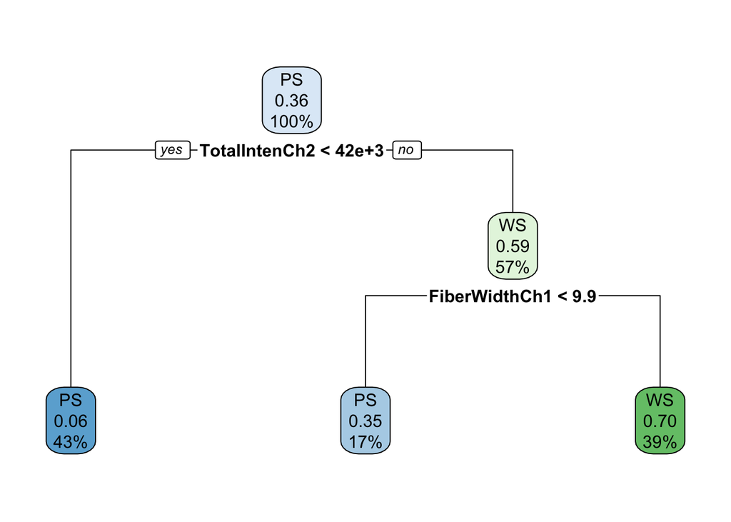

```r
rpart.plot(modFit$finalModel)
```

a = PS; b = WS; c = PS; d = Not possible to predict

## 3)

Load the olive oil data.

These data contain information on 572 different Italian olive oils from multiple regions in Italy. Fit a classification tree where Area is the outcome variable. Then predict the value of area for the following data frame using the tree command with all defaults

What is the resulting prediction? Is the resulting prediction strange? Why or why not?

```r
load("../data/olive")
olive = olive[,-1]
newdata = as.data.frame(t(colMeans(olive)))
head(olive)
```

```
  Area Palmitic Palmitoleic Stearic Oleic Linoleic Linolenic Arachidic Eicosenoic
1    1     1075          75     226  7823      672        36        60         29
2    1     1088          73     224  7709      781        31        61         29
3    1      911          54     246  8113      549        31        63         29
4    1      966          57     240  7952      619        50        78         35
5    1     1051          67     259  7771      672        50        80         46
6    1      911          49     268  7924      678        51        70         44
```

```r
head(newdata)
```

```
     Area Palmitic Palmitoleic  Stearic    Oleic Linoleic Linolenic Arachidic Eicosenoic
1 4.59965 1231.741    126.0944 228.8654 7311.748  980.528  31.88811   58.0979   16.28147
```

```r
# it seems it's not necessary to test it - insane. Bad formulated question/everything again
set.seed(125)
modFit <- rpart(Area ~ ., data=olive)

modFit
```

```
n= 572

node), split, n, deviance, yval
      * denotes terminal node

 1) root 572 3171.32000 4.599650
   2) Eicosenoic>=6.5 323  176.82970 2.783282
     4) Oleic>=7770.5 19   16.10526 1.315789 *
     5) Oleic< 7770.5 304  117.25000 2.875000 *
   3) Eicosenoic< 6.5 249  546.51410 6.955823
     6) Linoleic>=1053.5 98   21.88776 5.336735 *
     7) Linoleic< 1053.5 151  100.99340 8.006623
      14) Oleic< 7895 95   23.72632 7.515789 *
      15) Oleic>=7895 56   15.55357 8.839286 *
```

```r
predict(modFit, newdata)
```

```
    1
2.875
```

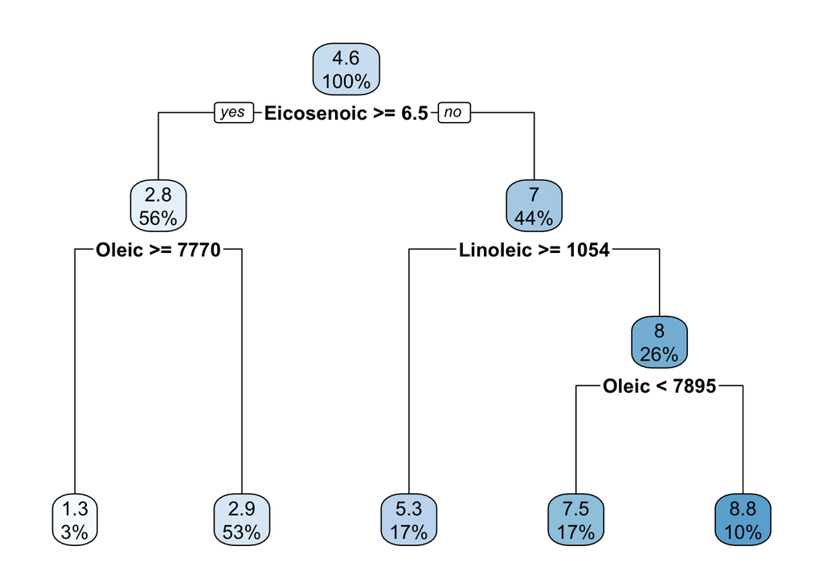

```r
rpart.plot(modFit)
```

## 4)

Load the South Africa Heart Disease Data and create training and test sets.

Then set the seed to 13234 and fit a logistic regression model (method=“glm”, be sure to specify family=“binomial”) with Coronary Heart Disease (chd) as the outcome and age at onset, current alcohol consumption, obesity levels, cumulative tabacco, type-A behavior, and low density lipoprotein cholesterol as predictors. Calculate the misclassification rate for your model using this function and a prediction on the “response” scale:

```r
data(SAheart)
set.seed(8484)
train = sample(1:dim(SAheart)[1],size=dim(SAheart)[1]/2,replace=F)
trainSA = SAheart[train,]
testSA = SAheart[-train,]
```

```r
set.seed(13234)
missClass = function(values,prediction){sum(((prediction > 0.5)*1) != values)/length(values)}
```

```r
modFit <- train(chd ~ age + alcohol + obesity + tobacco + typea + ldl,
                method="glm", family = "binomial", data=trainSA)

predictTrain <- predict(modFit)
missClass(trainSA$chd,predictTrain)
```

```
[1] 0.2727273
```

```r
predictTest <- predict(modFit, testSA)
missClass(testSA$chd,predictTest)
```

```
[1] 0.3116883
```

## 5)

Load the vowel.train and vowel.test data sets.

Set the variable y to be a factor variable in both the training and test set. Then set the seed to 33833. Fit a random forest predictor relating the factor variable y to the remaining variables. Read about variable importance in random forests here: http://www.stat.berkeley.edu/~breiman/RandomForests/cc_home.htm#ooberr The caret package uses by default the Gini importance.

Calculate the variable importance using the varImp function in the caret package. What is the order of variable importance?

(NOTE: Use randomForest() specifically, not caret, as there’s been some issues reported with that approach)

```r
data(vowel.train)
data(vowel.test)

vowel.train$y <- as.factor(vowel.train$y)
vowel.test$y <- as.factor(vowel.test$y)

set.seed(33833)

mod <- randomForest(y ~ ., data = vowel.train)
order(varImp(mod), decreasing = T)
```

```
 [1]  2  1  5  6  8  4  9  3  7 10
```